# Hospital patient satisfaction and pain management

Slobodan

2026-07-16

# Project overview

Patients undergoing stem cell injection therapy (autologous fat-derived or bone-marrow-derived) for pain management were followed with repeated patient-reported outcome surveys at scheduled intervals after their first visit (baseline, and nominal days 7, 14, 20, 30, 90, 180, 270 and 365). At each visit, patients rated their anxiety, depression, pain (intensity, behavior, interference, and an overall average), physical health, mental health, and perceived social role functioning. Not all participants made each of the visits, so the panel is not completely balanced.

This notebook asks two questions of that data:

1. **Trajectory** — Holding the repeated-measures structure of the data fixed, how do these nine outcomes change over the year following a patient’s first visit, relative to their own baseline?
2. **Therapy comparison** — Conditional on the (non-randomized) choice of stem cell source, is there evidence that fat-derived cells, bone-marrow-derived cells, both, or neither are associated with better outcomes?

Both questions are addressed with **linear mixed-effects models** (one random intercept per patient), which let each patient act as their own control while still pooling information across patients and visits. All p-values on multiple simultaneous contrasts are corrected for multiple testing (Benjamini–Hochberg FDR) so that the reported effects are not an artifact of running many tests.

**Methods and skills demonstrated:** longitudinal/repeated-measures design with irregular visit timing, linear mixed-effects modeling (`lme4`), estimated marginal means and multiplicity-corrected contrasts (`emmeans`), residual diagnostics for LMMs, time-varying exposure construction that avoids immortal time bias, and honest reporting of a comparison that does **not** survive multiple-testing correction.

# Data preparation

## Libraries and Data import

```r
library(dplyr)
library(lme4)
library(lmerTest)
library(emmeans)
library(ggplot2)
library(readxl)
library(gridExtra)

reduced_data <- read_excel("reduced data.xlsx")
```

## Visit-window alignment and variable cleanup

Not every patient was surveyed on the exact intended day (e.g., day 272 instead of day 270), so each recorded day is snapped to the nearest intended visit window before being treated as a factor. This keeps “day 270” comparable across patients even when a handful of surveys were returned a few days early or late. Three verbose survey-question column names are also renamed to short, analysis-friendly labels.

```r
visit_windows <- c(0, 7, 14, 20, 30, 90, 180, 270, 365)

map_to_visit_window <- function(days, windows = visit_windows) {
  days <- as.numeric(as.character(days))
  vapply(days, function(d) {
    if (is.na(d)) return(NA_real_)
    windows[which.min(abs(windows - d))]
  }, numeric(1))
}

reduced_data <- reduced_data %>%
  mutate(
    Days_raw    = as.numeric(as.character(Days)),
    Days_window = map_to_visit_window(Days_raw),
    Days        = factor(Days_window, levels = visit_windows)
  )%>%
  rename(
    Pain_average = `In the past 7 days... How would you rate your pain on average?`,
    fat_stem_cells = `Did you have fat derived stem cells harvested?`,
    bone_marrow_stem_cells = `Did you have bone marrow derived stem cells harvested?`
    )
```

# Modeling approach

Each outcome is modeled independently as:

$$\text{outcome} \sim \text{Days (factor)}
+ (1 \mid \text{Patient\_ID})$$

`Days` is fit as a factor (not numeric) because visits are irregularly spaced and effects are unlikely to be linear in time — a factor lets each visit window have its own estimated mean. The random intercept absorbs each patient’s stable baseline level, so the fixed-effect contrasts below are estimating within-patient change over time.

```r
fit_lmm_days <- function(data, outcome, patient_var = "Patient_ID",
                          days_var = "Days", days_numeric_var = "Days_numeric") {

  d <- data %>% filter(!is.na(.data[[outcome]]))

  form <- as.formula(paste0(outcome, " ~ ", days_var, " + (1 | ", patient_var, ")"))
  m <- lmer(form, data = d)

  singular <- isSingular(m)
  if (singular) {
    message("[", outcome, "] Singular/boundary fit: estimated between-patient ",
            "variance is ~0. Fixed-effect estimates are still usable, but this ",
            "usually means there isn't much within-patient replication to ",
            "distinguish patient-level from residual variance for this outcome.")
  }

  emm <- emmeans(m, as.formula(paste0("~ ", days_var)))

  ref_idx <- which(levels(d[[days_var]]) == "0")
  if (length(ref_idx) == 0) {
    warning("[", outcome, "] no Days == 0 level present; skipping baseline contrasts.")
    contrasts_vs_baseline <- NULL
  } else {
    contrasts_vs_baseline <- contrast(emm, method = "trt.vs.ctrl", ref = ref_idx,
                                       adjust = "fdr", infer = c(TRUE, TRUE))
  }

  omnibus <- tryCatch(anova(m), error = function(e) NULL)

  list(outcome = outcome, model = m, singular = singular,
       emmeans = emm, contrasts = contrasts_vs_baseline, omnibus = omnibus)
}
```

For each outcome, `plot_lmm_diagnostics()` below builds a residuals-vs-fitted plot and a normal Q-Q plot, so every model’s assumptions can be checked before its contrasts are trusted (see Model diagnostics).

```r
plot_lmm_diagnostics <- function(fit_result, save_dir = NULL) {
  m <- fit_result$model
  outcome <- fit_result$outcome

  df_diag <- data.frame(fitted = fitted(m), resid = resid(m))

  p1 <- ggplot(df_diag, aes(x = fitted, y = resid)) +
    geom_point(alpha = 0.5) +
    geom_hline(yintercept = 0, linetype = "dashed") +
    labs(title = paste(outcome, "- Residuals vs Fitted"), x = "Fitted", y = "Residual") +
    theme_classic()

  qq_df <- as.data.frame(qqnorm(resid(m), plot.it = FALSE))
  p2 <- ggplot(qq_df, aes(x = x, y = y)) +
    geom_point(alpha = 0.5) +
    geom_qq_line(aes(sample = y)) +
    labs(title = paste(outcome, "- Normal Q-Q of residuals"),
         x = "Theoretical quantiles", y = "Sample quantiles") +
    theme_classic()

  if (!is.null(save_dir)) {
    ggsave(file.path(save_dir, paste0(outcome, "_resid_vs_fitted.png")), p1, width = 5, height = 4)
    ggsave(file.path(save_dir, paste0(outcome, "_qq.png")), p2, width = 5, height = 4)
  }

  list(resid_vs_fitted = p1, qq = p2)
}
```

## Fitting the nine outcome models

```r
outcomes <- c("Anxiety", "Depression", "Pain_intensity", "Pain_behavior",
              "Pain_interference", "Pain_average", "Physical_health", "Mental_health",
              "Health_Perception_Social_Roles")

lmm_results <- lapply(outcomes, function(v) fit_lmm_days(reduced_data, v))
names(lmm_results) <- outcomes

data.frame(
  outcome  = outcomes,
  singular = sapply(lmm_results, `[[`, "singular")
)
```

|  | outcome | singular |
| --- | --- | --- |
| Anxiety | Anxiety | FALSE |
| Depression | Depression | FALSE |
| Pain_intensity | Pain_intensity | FALSE |
| Pain_behavior | Pain_behavior | FALSE |
| Pain_interference | Pain_interference | FALSE |
| Pain_average | Pain_average | FALSE |
| Physical_health | Physical_health | FALSE |
| Mental_health | Mental_health | FALSE |
| Health_Perception_Social_Roles | Health_Perception_Social_Roles | FALSE |

None of the nine models produced a singular (boundary) fit, so there was enough within-patient replication at each visit window to separate patient-level variance from residual variance for every outcome.

## Contrasts against baseline

Every follow-up visit is compared back to day 0 within each outcome, with the eight comparisons for that outcome FDR-corrected together.

```r
results_table <- do.call(rbind, lapply(lmm_results, function(r) {
  if (is.null(r$contrasts)) return(NULL)
  df <- as.data.frame(r$contrasts)
  df$outcome <- r$outcome
  df
}))

results_table <- results_table %>%
  select(outcome, contrast, estimate, SE, df, lower.CL, upper.CL, t.ratio, p.value) %>%
  arrange(outcome, contrast)

print(results_table)
```

```
##                           outcome        contrast    estimate         SE
## 1                         Anxiety  Days14 - Days0 -0.35747257 0.18669701
## 2                         Anxiety Days180 - Days0 -0.04020267 0.11199149
## 3                         Anxiety  Days20 - Days0 -0.28883206 0.15643097
## 4                         Anxiety Days270 - Days0  0.06232951 0.11883427
## 5                         Anxiety  Days30 - Days0 -0.01566670 0.13386929
## 6                         Anxiety Days365 - Days0  0.10871114 0.11554977
## 7                         Anxiety   Days7 - Days0  0.93220283 0.57251421
## 8                         Anxiety  Days90 - Days0 -0.08921582 0.09632416
## 9                      Depression  Days14 - Days0 -0.24498235 0.20785873
## 10                     Depression Days180 - Days0  0.12543364 0.10516362
## 11                     Depression  Days20 - Days0 -0.10290772 0.15490775
## 12                     Depression Days270 - Days0 -0.05209079 0.11524792
## 13                     Depression  Days30 - Days0  0.04416464 0.14936767
## 14                     Depression Days365 - Days0  0.21867884 0.10992072
```

[output cut: 107 more lines]

**Reading the table:** the clearest signal is in the pain-related outcomes.

`Pain_intensity` improves significantly by day 14 (p = 0.025) and stays improved through day 90 (p = 0.010), `Pain_behavior` improves significantly by day 90 (p = 0.0016), and `Pain_interference` improves significantly at day 20 (p = 0.019) and day 90 (p = 0.010). `Pain_average` is directionally lower at every follow-up from day 90 onward and reaches significance at day 90 (p = 0.013), with day 180–365 hovering just above the 0.05 threshold (p ≈ 0.06–0.10) — consistent with real but modest, somewhat noisier improvement late in follow-up.

By contrast, none of the psychological or general-health outcomes — `Anxiety`, `Depression`, `Physical_health`, `Mental_health`, or `Health_Perception_Social_Roles` — reach significance at *any* follow-up window. Numerically their estimated means barely move from baseline. Taken together, this pattern suggests the therapy’s detectable benefit in this sample is concentrated in pain measures specifically, not in broader psychological wellbeing or self-rated general health — though absence of significance for the latter group is also consistent with those outcomes simply having less room to move, or with the study being underpowered to detect small effects.

## Model-based estimated means

These are the same per-visit means visualized in the trajectory plots below, produced directly from each model rather than raw sample means, so they account for the repeated-measures structure and any missingness pattern in who was surveyed at which visit.

```r
emm_table <- do.call(rbind, lapply(lmm_results, function(r) {
  df <- as.data.frame(r$emmeans)
  df$outcome <- r$outcome
  df
}))
print(emm_table)
```

```
##  Days emmean     SE    df lower.CL upper.CL outcome
##  0      2.01 0.0810 118.2    1.854     2.18 Anxiety
##  7      2.95 0.5732 203.0    1.817     4.08 Anxiety
##  14     1.66 0.1888 197.2    1.285     2.03 Anxiety
##  20     1.73 0.1592 208.6    1.412     2.04 Anxiety
##  30     2.00 0.1370 213.0    1.729     2.27 Anxiety
##  90     1.93 0.1006 176.7    1.727     2.12 Anxiety
##  180    1.97 0.1157 204.8    1.746     2.20 Anxiety
##  270    2.08 0.1215 208.8    1.837     2.32 Anxiety
##  365    2.12 0.1191 207.9    1.888     2.36 Anxiety
##  0      1.64 0.0752 120.2    1.490     1.79 Depression
##  7      3.25 0.6382 121.0    1.987     4.51 Depression
##  14     1.39 0.2089 185.0    0.981     1.81 Depression
##  20     1.54 0.1566 196.4    1.227     1.84 Depression
##  30     1.68 0.1508 198.6    1.385     1.98 Depression
```

[output cut: 58 more lines]

# Model diagnostics

Before trusting any of the contrasts above, it’s worth checking that each model’s residuals behave the way an LMM assumes: roughly constant spread across fitted values, and roughly normal. The loop below reuses `plot_lmm_diagnostics()` (already defined earlier) across all nine outcomes and lays each pair of plots side by side.

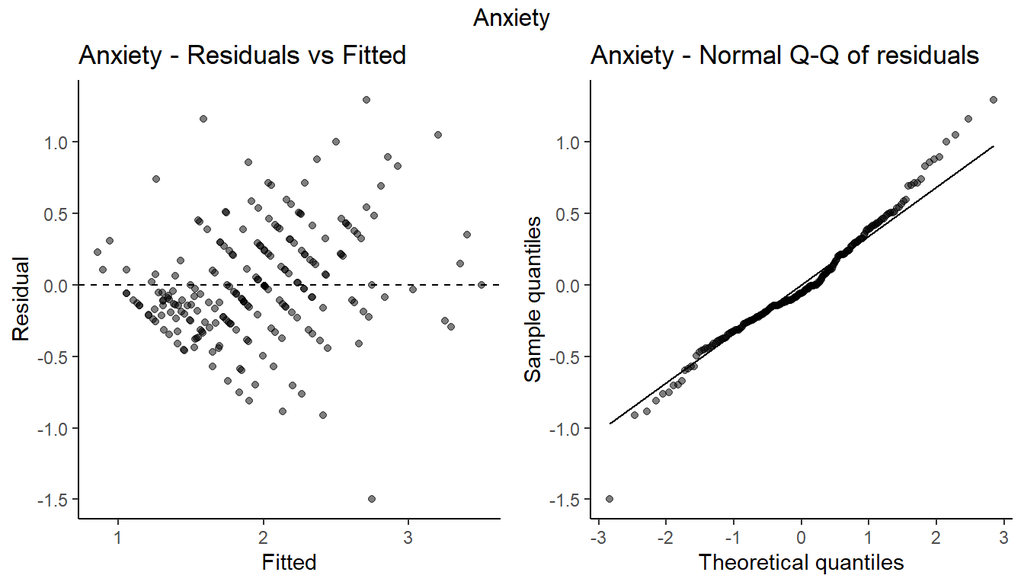

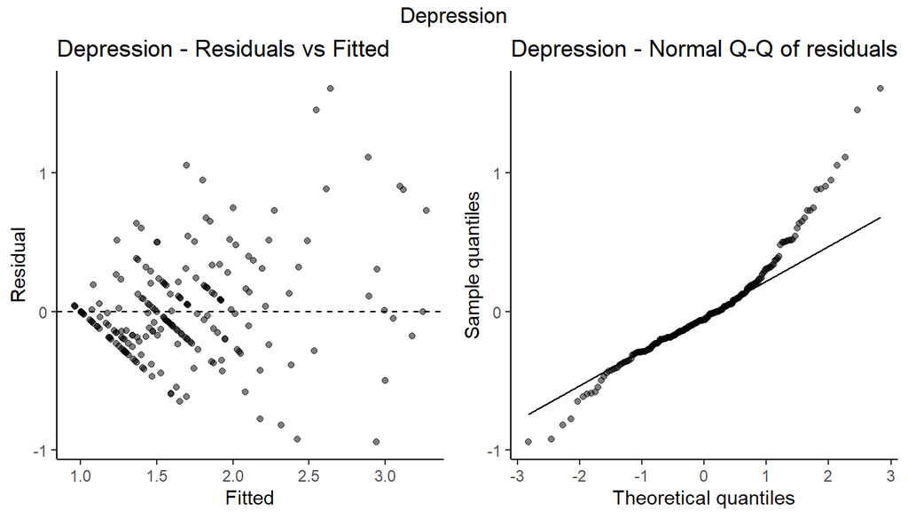

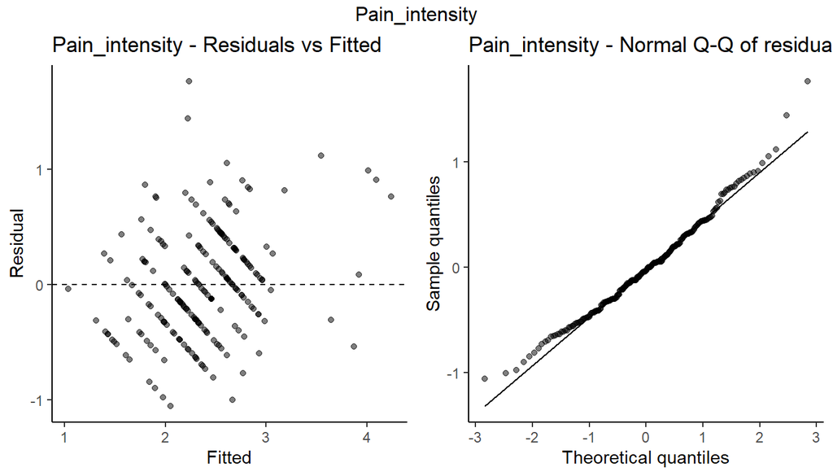

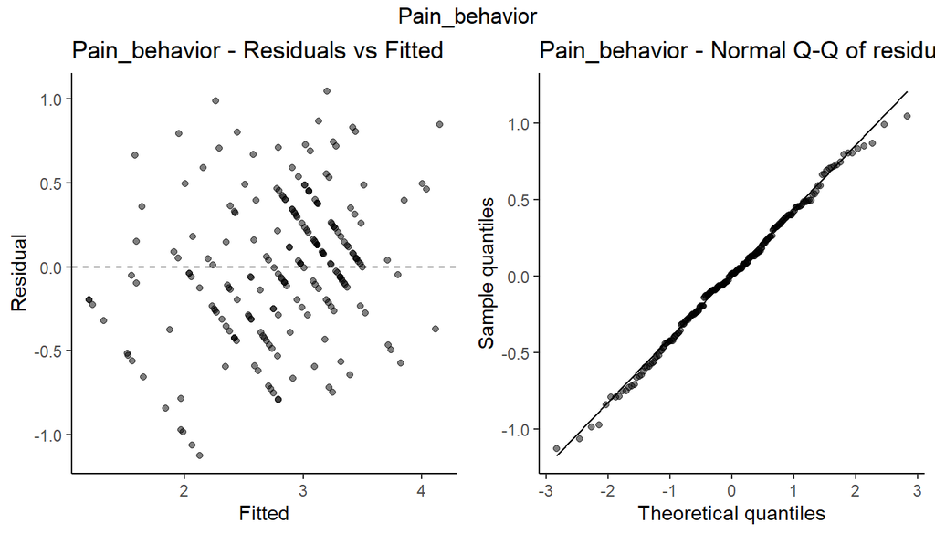

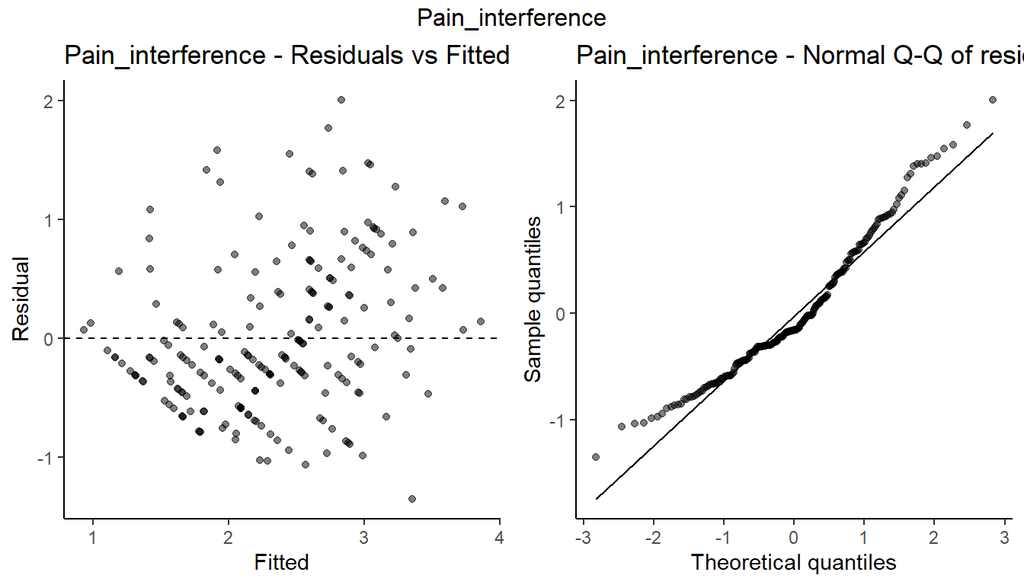

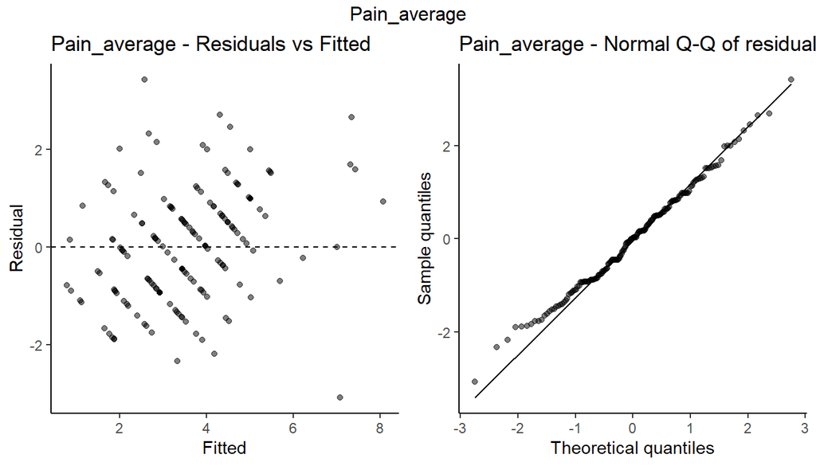

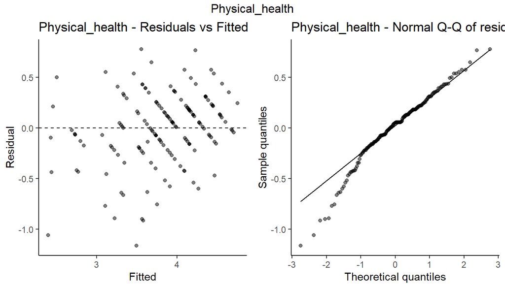

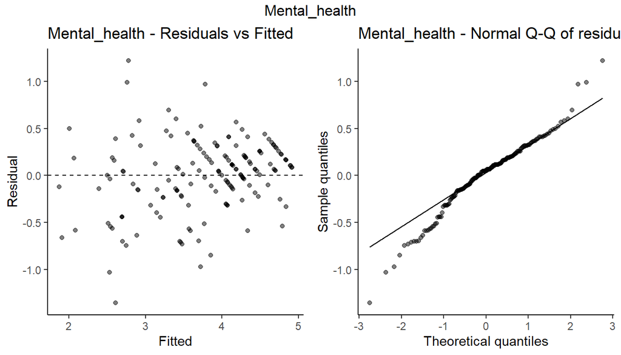

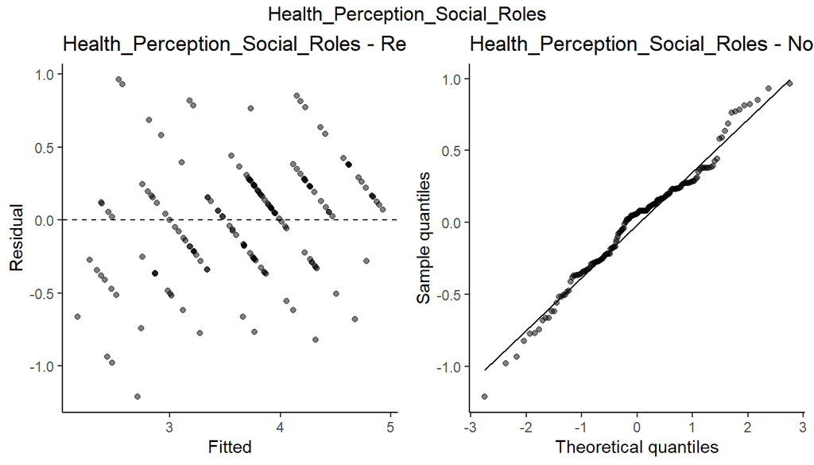

```r
for (outcome in outcomes) {
  diag_plots <- plot_lmm_diagnostics(lmm_results[[outcome]])
  grid.arrange(diag_plots$resid_vs_fitted, diag_plots$qq, ncol = 2, top = outcome)
}
```

These slight deviations from model assumptions are a limitation on the generalizability of the results and point to a need for a larger sample and consideration of alternative models in future research.

# Outcome trajectories over time

Next, we look at how the values of the variables of interest have changed over time. The estimates are based on the models above, which is an effective way to control for imbalance in how many patients were surveyed at each window.

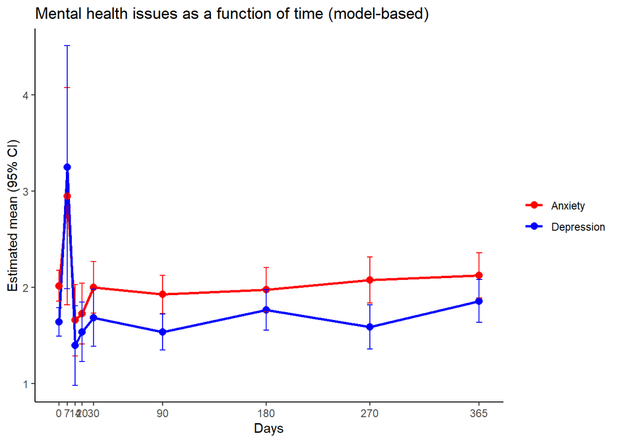

```r
emm_table <- emm_table %>%
  mutate(Days_numeric = as.numeric(as.character(Days)))

plot_group <- function(emm_table, vars, colors, title, ylab) {
  d <- emm_table %>% filter(outcome %in% vars)
  d %>%
    ggplot(aes(x = Days_numeric, y = emmean, color = outcome)) +
    geom_line(linewidth = 1) +
    geom_point(size = 2.5) +
    geom_errorbar(aes(ymin = lower.CL, ymax = upper.CL), width = 5) +
    scale_x_continuous(breaks = sort(unique(d$Days_numeric))) +
    scale_color_manual(values = colors) +
    xlab("Days") + ylab(ylab) + ggtitle(title) +
    labs(color = NULL) +
    theme_classic()
}

plot_group(emm_table, c("Anxiety", "Depression"),
           c("Anxiety" = "red", "Depression" = "blue"),
           "Mental health issues as a function of time (model-based)",
           "Estimated mean (95% CI)")
```

Both anxiety and depression sit close to their baseline levels across the full year of follow-up, with confidence intervals for each later visit overlapping the day-0 estimate — visually confirming the “no significant change vs. baseline” result from the contrasts table above. The wide interval at day 7 for depression in particular reflects the small, noisy sample at that window rather than a real spike.

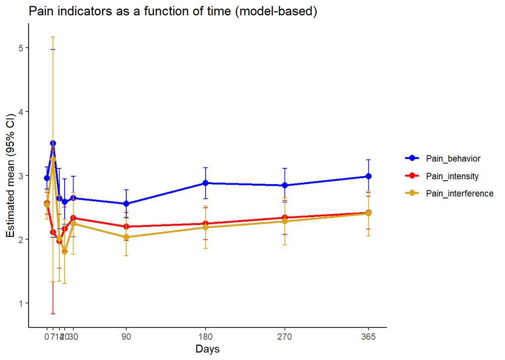

```r
plot_group(emm_table, c("Pain_intensity", "Pain_behavior", "Pain_interference"),
           c("Pain_intensity" = "red", "Pain_behavior" = "blue", "Pain_interference" = "goldenrod"),
           "Pain indicators as a function of time (model-based)",
           "Estimated mean (95% CI)")
```

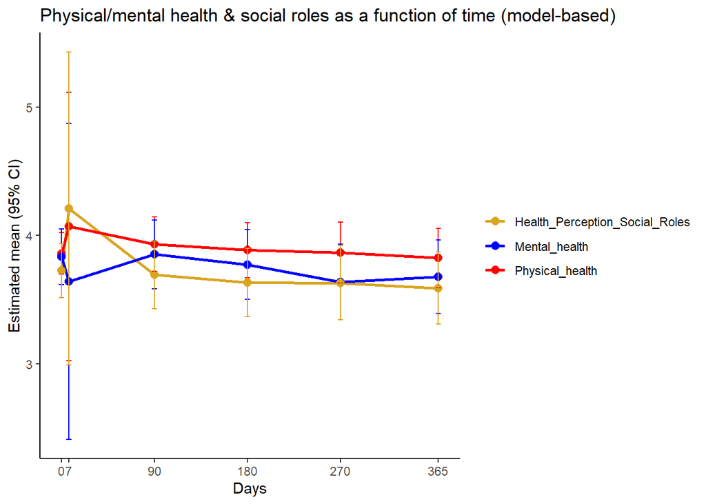

```r
plot_group(emm_table, c("Physical_health", "Mental_health", "Health_Perception_Social_Roles"),
           c("Physical_health" = "red", "Mental_health" = "blue", "Health_Perception_Social_Roles" = "goldenrod"),
           "Physical/mental health & social roles as a function of time (model-based)",
           "Estimated mean (95% CI)")
```

These three general-health measures stay essentially flat across the year, all hovering within roughly half a point of their baseline value and never breaking away from the day-0 confidence interval. Combined with the pain-indicator plot above, the overall picture is a therapy that tracks with improvement in patient-reported *pain* specifically, without a corresponding detectable shift in broader physical/mental self-assessment over the same period.

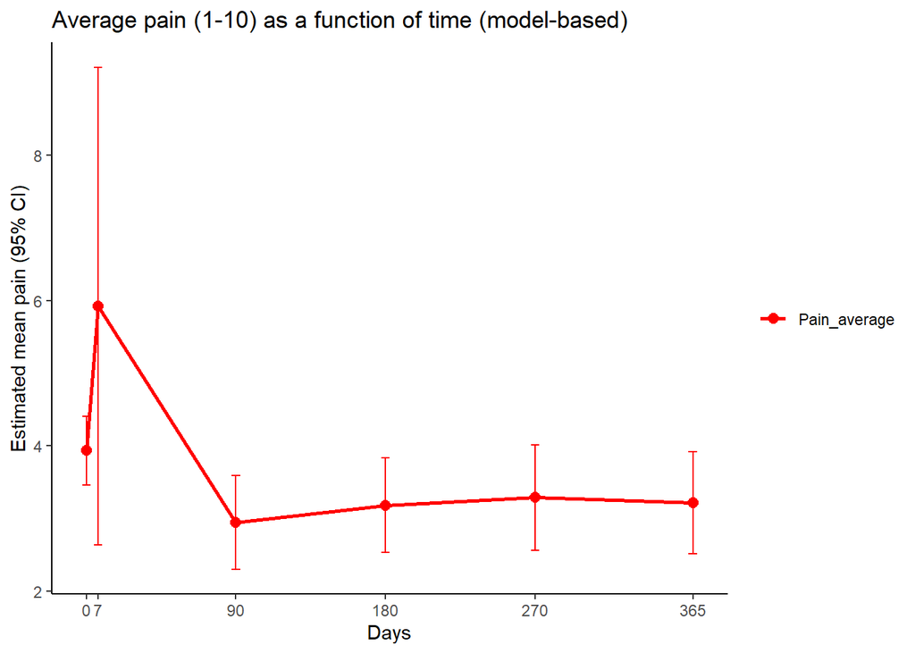

```r
plot_group(emm_table, "Pain_average", c("Pain_average" = "red"),
           "Average pain (1-10) as a function of time (model-based)",
           "Estimated mean pain (95% CI)")
```

Average pain (on the 1–10 scale) shows the most dramatic-looking swing of any outcome — a spike to ~5.9 at day 7 with a very wide interval, then a drop to ~3 by day 90 that holds through day 365. Note this outcome has no model-based estimate at days 14/20/30 (it wasn’t collected at those windows), so the apparent day-7-to-day-90 “drop” spans a wide gap and should be read as a coarse before/after comparison rather than a smooth week-by-week decline.

# Stem cell source and time-varying exposure

Next, we compare health trajectories based on whether stem cell therapy was used and which type (fat vs. bone marrow). We do this by first assigning each patient a **time-varying exposure status** at every visit: before any recorded use of a given cell type, the patient is coded “unexposed” for that visit; from the first visit where use is recorded onward, they’re coded “exposed.” This deliberately avoids **immortal time bias** — a patient is never credited with the benefits of a treatment before it was actually recorded as having happened.

```r
reduced_data <- reduced_data %>%
  mutate(Days_numeric = as.numeric(as.character(Days))) %>%
  arrange(Patient_ID, Days_numeric)


build_time_varying_exposure <- function(data, indicator, patient_var = "Patient_ID", days_var = "Days_numeric") {
  ever_positive <- data %>%
    filter(.data[[indicator]] == 1) %>%
    group_by(.data[[patient_var]]) %>%
    summarise(treatment_day = min(.data[[days_var]]), .groups = "drop")

  ever_recorded <- data %>%
    filter(!is.na(.data[[indicator]])) %>%
    distinct(.data[[patient_var]]) %>%
    pull(.data[[patient_var]])

  data %>%
    left_join(ever_positive, by = patient_var) %>%
    mutate(
      exposure_tv = case_when(
        !is.na(treatment_day) & .data[[days_var]] >= treatment_day ~ 1,
        !is.na(treatment_day) & .data[[days_var]] <  treatment_day ~ 0,
        is.na(treatment_day) & .data[[patient_var]] %in% ever_recorded ~ 0,
        TRUE ~ NA_real_
      )
    ) %>%
    select(-treatment_day)
}

reduced_data <- reduced_data %>%
  build_time_varying_exposure("fat_stem_cells") %>%
  rename(fat_exposed_tv = exposure_tv) %>%
  build_time_varying_exposure("bone_marrow_stem_cells") %>%
  rename(bone_marrow_exposed_tv = exposure_tv)

reduced_data <- reduced_data %>%
  mutate(
    stem_group_tv = case_when(
      is.na(fat_exposed_tv) | is.na(bone_marrow_exposed_tv) ~ NA_character_,
      fat_exposed_tv == 1 & bone_marrow_exposed_tv == 1 ~ "both",
      fat_exposed_tv == 1 & bone_marrow_exposed_tv == 0 ~ "fat_only",
      fat_exposed_tv == 0 & bone_marrow_exposed_tv == 1 ~ "bone_marrow_only",
      fat_exposed_tv == 0 & bone_marrow_exposed_tv == 0 ~ "none",
      TRUE ~ NA_character_
    ),
    stem_group_tv = factor(stem_group_tv, levels = c("none", "fat_only", "bone_marrow_only", "both"))
  )

table(reduced_data$stem_group_tv, useNA = "always")
```

```
##
##             none         fat_only bone_marrow_only             both
##               21                6               25               89
##             <NA>
##              211
```

Two things stand out in this table. First, `both` is by far the largest group (89 patient-visits) — most patients who received either type of stem cell therapy received both. Second, **211 patient-visits have unknown exposure status** (never-recorded indicator for at least one cell type), which is larger than any single known group. Any comparison below is implicitly conditioned on the subset of patient-visits where exposure was actually recorded, and that’s an incomplete slice of the full dataset.

Since there are unfortunately no patient attributes present in the data that could be used to design propensity scores, we use each patient’s baseline value as a covariate in order to observe the effects of different stem cell therapies over time, as a partial (not full) adjustment for the fact that exposure was not randomized.

```r
outcomes <- c("Anxiety", "Depression", "Pain_intensity", "Pain_behavior",
              "Pain_interference", "Pain_average", "Physical_health", "Mental_health",
              "Health_Perception_Social_Roles")
exposures <- c("fat_exposed_tv", "bone_marrow_exposed_tv")

fit_exposure_comparison <- function(data, outcome, exposure_var, patient_var = "Patient_ID", days_var = "Days") {

  baseline_vals <- data %>%
  filter(Days_numeric == 0) %>%
  group_by(.data[[patient_var]]) %>%
  slice_min(order_by = abs(Days_raw), n = 1, with_ties = FALSE) %>%
  ungroup() %>%
  select(all_of(patient_var), baseline_val = all_of(outcome))

  base_data <- data %>%
    filter(Days_numeric > 0) %>%
    filter(!is.na(.data[[outcome]]), !is.na(.data[[exposure_var]])) %>%
    mutate(exposure_f = factor(.data[[exposure_var]], levels = c(0, 1), labels = c("no", "yes")))

  # prefer baseline-adjusted model; fall back to unadjusted if too few rows have baseline too
  with_baseline <- base_data %>%
  left_join(baseline_vals, by = patient_var, relationship = "many-to-one") %>%
  filter(!is.na(baseline_val)) %>%
  droplevels()
  use_baseline <- nrow(with_baseline) >= 15 && nlevels(with_baseline$exposure_f) == 2 &&
    min(table(with_baseline$exposure_f)) >= 5

  if (use_baseline) {
    model_data <- with_baseline
    form <- as.formula(paste0(outcome, " ~ ", days_var, " + exposure_f + baseline_val + (1 | ", patient_var, ")"))
    adjustment <- "Days + baseline"
  } else {
    model_data <- base_data %>% droplevels()
    form <- as.formula(paste0(outcome, " ~ ", days_var, " + exposure_f + (1 | ", patient_var, ")"))
    adjustment <- "Days only (too few rows had both baseline and exposure known)"
  }

  if (nrow(model_data) < 10 || nlevels(model_data$exposure_f) < 2 || min(table(model_data$exposure_f)) < 3) {
    message("[", outcome, " / ", exposure_var, "] Skipped: n = ", nrow(model_data),
            ", group sizes = ", paste(table(model_data$exposure_f), collapse = " vs "))
    return(NULL)
  }

  m <- tryCatch(lmer(form, data = model_data), error = function(e) e)
  if (inherits(m, "error")) {
    message("[", outcome, " / ", exposure_var, "] Model failed: ", conditionMessage(m))
    return(NULL)
  }
  if (isSingular(m)) message("[", outcome, " / ", exposure_var, "] Singular fit -- interpret cautiously.")

  emm <- emmeans(m, ~ exposure_f)
  ctr <- contrast(emm, method = "revpairwise", adjust = "none", infer = c(TRUE, TRUE))

  list(outcome = outcome, exposure = exposure_var, model = m, n = nrow(model_data),
       adjustment = adjustment, emmeans = emm, contrasts = ctr)
}

all_results <- list()
for (o in outcomes) {
  for (ex in exposures) {
    res <- fit_exposure_comparison(reduced_data, o, ex)
    if (!is.null(res)) all_results[[paste(o, ex, sep = "__")]] <- res
  }
}

cat("Models successfully fit:", length(all_results), "out of", length(outcomes) * length(exposures), "\n")
```

```
## Models successfully fit: 18 out of 18
```

All 18 outcome × exposure-type combinations fit successfully.

```r
if (length(all_results) == 0) {
  message("No exposure comparisons could be fit -- check group sizes above before loosening further.")
  results_table <- NULL
} else {
  results_table <- do.call(rbind, lapply(all_results, function(r) {
    df <- as.data.frame(r$contrasts)
    df$outcome <- r$outcome
    df$exposure <- r$exposure
    df$n_obs <- r$n
    df$adjustment <- r$adjustment
    df
  })) %>%
    select(outcome, exposure, n_obs, adjustment, contrast, estimate, SE, lower.CL, upper.CL, t.ratio, p.value) %>%
    arrange(outcome, exposure)
}

results_table$p_adj <- p.adjust(results_table$p.value, method = "fdr")
print(results_table)
```

```
##                           outcome               exposure n_obs      adjustment
## 1                         Anxiety bone_marrow_exposed_tv    67 Days + baseline
## 2                         Anxiety         fat_exposed_tv    67 Days + baseline
## 3                      Depression bone_marrow_exposed_tv    65 Days + baseline
## 4                      Depression         fat_exposed_tv    65 Days + baseline
## 5  Health_Perception_Social_Roles bone_marrow_exposed_tv    56 Days + baseline
## 6  Health_Perception_Social_Roles         fat_exposed_tv    56 Days + baseline
## 7                   Mental_health bone_marrow_exposed_tv    56 Days + baseline
## 8                   Mental_health         fat_exposed_tv    56 Days + baseline
## 9                    Pain_average bone_marrow_exposed_tv    56 Days + baseline
## 10                   Pain_average         fat_exposed_tv    56 Days + baseline
## 11                  Pain_behavior bone_marrow_exposed_tv    65 Days + baseline
## 12                  Pain_behavior         fat_exposed_tv    65 Days + baseline
## 13                 Pain_intensity bone_marrow_exposed_tv    68 Days + baseline
## 14                 Pain_intensity         fat_exposed_tv    68 Days + baseline
```

[output cut: 42 more lines]

**After correcting for multiple comparisons, there is no statistically reliable evidence that fat-derived cells, bone-marrow-derived cells, or their combination outperform non-use for any of the nine outcomes measured here.** This doesn’t mean there’s no true difference between therapies — group sizes for some comparisons are modest (as small as the “both” vs. other groups split allows) and the analysis can only adjust for baseline score, not for whatever unmeasured factors led a clinician or patient to choose one therapy over another — but it does mean this dataset, as analyzed, cannot support a claim that one stem cell source is better than another.

## Visualizing outcomes by exposure group

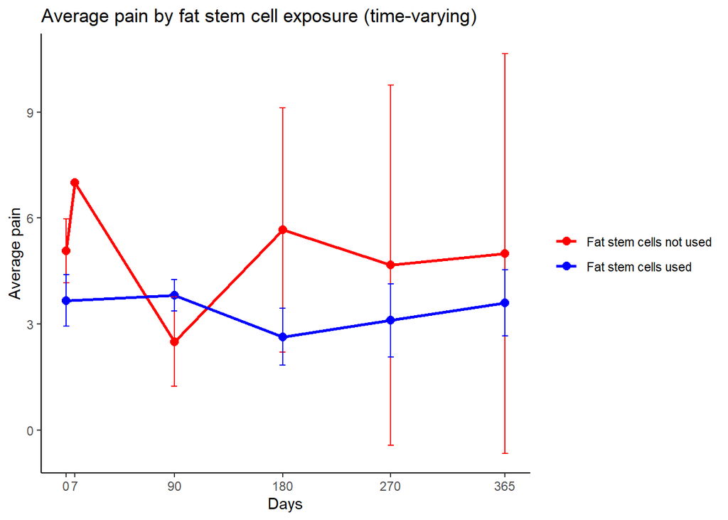

```r
#  Two-group version: single exposure variable (fat OR bone marrow)
plot_outcome_by_exposure <- function(data, outcome, exposure_var,
                                      group_labels, group_colors,
                                      title = NULL, ylab = outcome) {

  summary_df <- data %>%
    filter(!is.na(.data[[outcome]]), !is.na(.data[[exposure_var]])) %>%
    mutate(group = factor(.data[[exposure_var]], levels = c(0, 1), labels = group_labels)) %>%
    group_by(Days_numeric, group) %>%
    summarise(
      n    = n(),
      mean = mean(.data[[outcome]], na.rm = TRUE),
      se   = sd(.data[[outcome]], na.rm = TRUE) / sqrt(n),
      .groups = "drop"
    )

  ggplot(summary_df, aes(x = Days_numeric, y = mean, color = group)) +
    geom_line(linewidth = 1) +
    geom_point(size = 2.5) +
    geom_errorbar(aes(ymin = mean - 1.96 * se, ymax = mean + 1.96 * se), width = 5) +
    scale_x_continuous(breaks = sort(unique(summary_df$Days_numeric))) +
    scale_color_manual(values = group_colors) +
    xlab("Days") + ylab(ylab) + ggtitle(title) +
    labs(color = NULL) +
    theme_classic()
}

#  Four-group version: combined fat / bone marrow / both / neither
plot_outcome_by_group <- function(data, outcome, title = NULL, ylab = outcome,
                                   y_limits = NULL) {

  group_levels <- c("none", "fat_only", "bone_marrow_only", "both")
  group_colors <- c(none = "goldenrod", fat_only = "red",
                     bone_marrow_only = "blue", both = "purple")
  group_labels <- c(none = "Not indicated", fat_only = "Fat stem cells only",
                     bone_marrow_only = "Bone marrow stem cells only",
                     both = "Fat + bone marrow stem cells")

  summary_df <- data %>%
    filter(!is.na(.data[[outcome]]), !is.na(stem_group_tv)) %>%
    mutate(stem_group_tv = factor(stem_group_tv, levels = group_levels)) %>%
    group_by(Days_numeric, stem_group_tv) %>%
    summarise(
      n    = n(),
      mean = mean(.data[[outcome]], na.rm = TRUE),
      se   = sd(.data[[outcome]], na.rm = TRUE) / sqrt(n),
      .groups = "drop"
    )

  p <- ggplot(summary_df, aes(x = Days_numeric, y = mean, color = stem_group_tv)) +
    geom_line(linewidth = 1) +
    geom_point(size = 2.5) +
    geom_errorbar(aes(ymin = mean - 1.96 * se, ymax = mean + 1.96 * se), width = 5) +
    scale_x_continuous(breaks = sort(unique(summary_df$Days_numeric))) +
    scale_color_manual(values = group_colors, labels = group_labels) +
    xlab("Days") + ylab(ylab) + ggtitle(title) +
    labs(color = NULL) +
    theme_classic()

  if (!is.null(y_limits)) p <- p + scale_y_continuous(limits = y_limits)
  p
}

# Pain by fat stem cell exposure (time-varying)
plot_outcome_by_exposure(
  reduced_data, "Pain_average", "fat_exposed_tv",
  group_labels = c("Fat stem cells not used", "Fat stem cells used"),
  group_colors = c("Fat stem cells not used" = "red", "Fat stem cells used" = "blue"),
  title = "Average pain by fat stem cell exposure (time-varying)",
  ylab  = "Average pain"
)
```

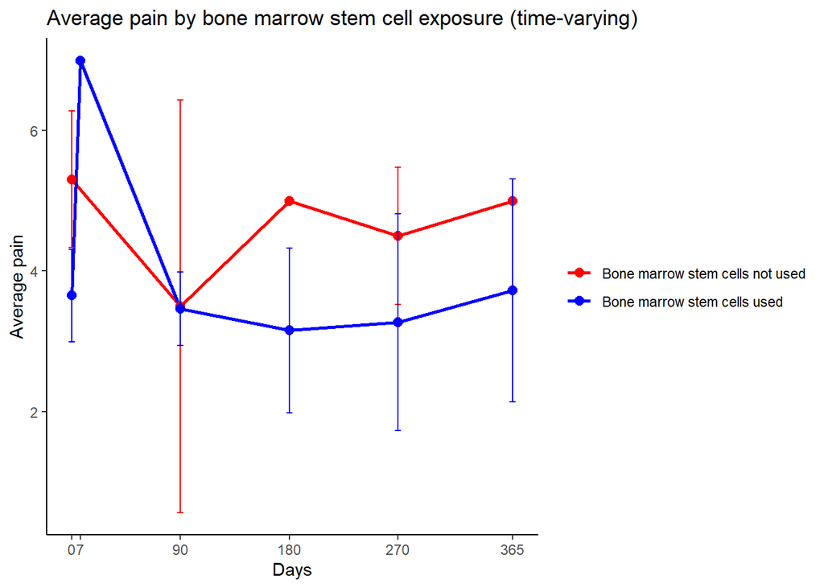

```r
# Pain by bone marrow stem cell exposure (time-varying)
plot_outcome_by_exposure(
  reduced_data, "Pain_average", "bone_marrow_exposed_tv",
  group_labels = c("Bone marrow stem cells not used", "Bone marrow stem cells used"),
  group_colors = c("Bone marrow stem cells not used" = "red", "Bone marrow stem cells used" = "blue"),
  title = "Average pain by bone marrow stem cell exposure (time-varying)",
  ylab  = "Average pain"
)
```

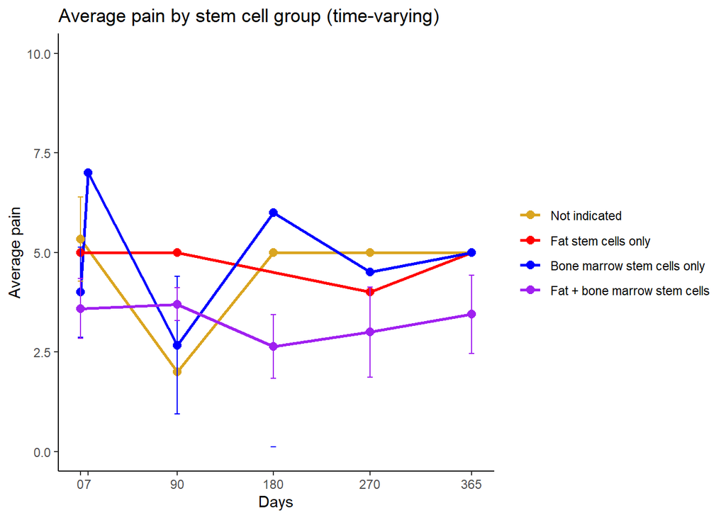

```r
# Pain by combined stem cell group (time-varying)
plot_outcome_by_group(
  reduced_data, "Pain_average",
  title    = "Average pain by stem cell group (time-varying)",
  ylab     = "Average pain",
  y_limits = c(0, 10)   # Pain_average is on a 1-10 scale; drop/adjust for other outcomes
)
```

Visually, the exposed and unexposed groups largely overlap for most of follow-up, with confidence intervals that cross throughout — the visual counterpart of the “no comparison survives FDR correction” result above. The `none` group (goldenrod, n = 21) in the combined-group plot is noticeably noisier than `both` (purple, n = 89), simply because it has far fewer patients contributing to each visit’s average; differences between groups late in follow-up should be read with that imbalance in mind rather than as evidence of a true divergence.